# Running the suite of scripts to fit the R shiny emulator

Bertrand Nortier

2022-10-12

# Installation of Database for running the Matlab script

## The explanation below was written by Nathan Owen (Note that some of these steps may need to be modified with the more recent versions of PostgreSQL):

Download PostgreSQL from https://www.postgresql.org/download/. Go for version 12 and launch the installer. The installation will include pgAdmin 4, which is a GUI for interacting with a PostgreSQL database which most of us use. Use ‘postgres’ for both the username and password, and make sure the port is 5432.

During the installation you will also be asked to launch Stack Builder, where you can install additional packages. You will need to install PostGIS (for spatial databases), and all the database drivers (e.g. ODBC, these are used to access the database from MATLAB).

Restoring the NEV database Open pgAdmin 4 (for me the program opens as a tab in Google Chrome, not entirely sure why but it works!). Click on ‘Servers’ on the left hand side (you may need to login using your username and password at this point). Create a new database by right-clicking on ‘Databases’ and selecting ‘Create->Database…’. Call this database ‘nev’.

You will need to enable PostGIS for this database so that we can work with spatial data. The easiest way to do this is to right-click on the ‘nev’ database and select ‘Query Tool…’. In the editor which appears, type ‘CREATE EXTENSION postgis’ and click run/execute (the play/triangle symbol).

Now you can restore the schemas (a collection of tables) which the NEV model depends on. You will find backup files for these schemas in the Database Backups folder which is within the Model Data folder. From within pgAdmin 4, right-click on the ‘nev’ database and select ‘Restore…’. Click on the ‘…’ symbol next to the ‘Filename’ and navigate to one of the ‘.backup’ files. The restoration process should begin and depending on the size of the backup file, could take 5-10 minutes. If this is successful you should see a schema appear within the ‘nev’ database.

# Running the Matlab Code after the successful installation of the database

The folder ``Turing-FastTrack_PolicyLevers’’ contains the Matlab model

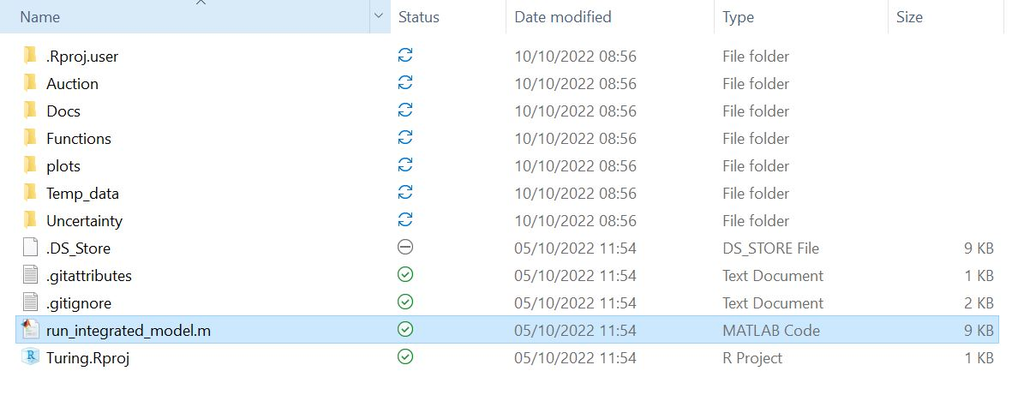

function ‘’run_integrated_model’’ starts with a connection to the database. The function to connect to the database is under ’’Functions_connect_database.m’’

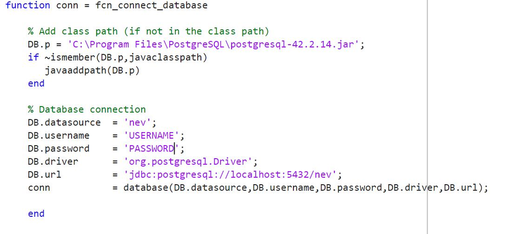

First, replace DB.p by the correct path pointing to the .jar file. If the file is not present, I saved a copy of the file in the `Supplementation file folder’. You may want to check the version of the .jar file that should be used. Next, replace DB.username and DB.password by the correct username and password to access the database. You can then go to the ‘’SupplementaryFiles’’ folder and copy the file ‘’A_run_integrated_model_Modif_Sep2022.m’’ into the ‘’Turing-FastTrack_PolicyLevers’’ folder. This file was stored separately so that the folder ‘’Turing-FastTrack_PolicyLevers’’ is kept.  
Change the name of the temp_data_folder in the ‘’A_run_integrated_model_Modif_Sep2022.m’’ file to a folder you want to use to store the result files. For example let’s call it ‘’ExampleFolder’’.

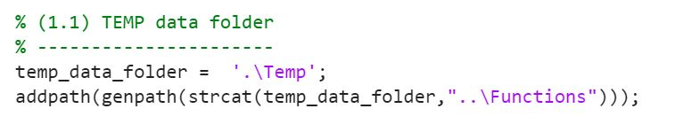

The ExampleFolder should contain the 3 files prior to running the Matlab Code:

[figure not shown]

These 3 files can be copied into the ExampleFolder from the folder: ‘’Turing-FastTrack_PolicyLevers/Temp_data’’  
The current Matlab file contains the calculation of 64 points. 50 of them are picked on a Latin Hypercube, 14 others are points calculated at extreme points of the space to improve fitting.

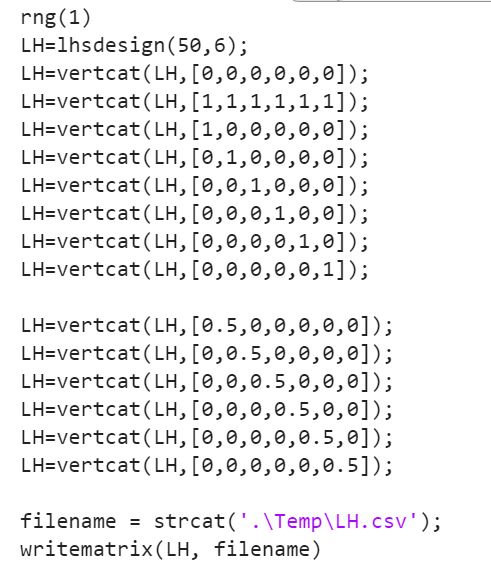

To run the examples, change the range on which the code is run. Here only examples 51:64 are calculated. To run all the examples change this to 1:64. The multipliers of the 6 input values can be changed at the top of this loop. Here we have 0-10000,…,1b-3b.

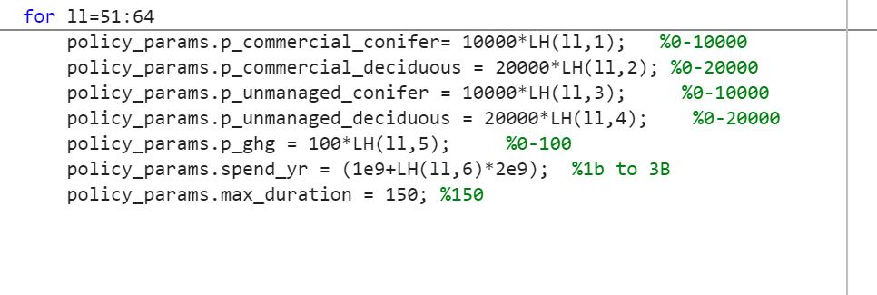

After running the Matlab code, mutliple files will be created in the ExampleFolder.

```
  1- the NetGHG time series
  2- the planting maps of managed conifers for years 1-150
  3- the planting maps of unmanaged conifers
  4- the planting maps of managed deciduous trees
  5- the planting maps of unmanaged deciduous trees
  6- the year spent for the 4 types of trees
  7- the time series of the percentage change of food.
```

# B-NetGHGTimeSeriesBasisAndGPEmul.r

This second file aim is to obtain vector basis for the NetGHG time series, the basis multipliers. Change the name of the folder. In B-NetGHGTimeSeriesBasisAndGPEmul.r, the folder is used both for input and ouput. Then it should contain the NetGHG time series files output from the Matlab code: (ghg_i.csv) as well as the set of input points of the model (LH.csv).

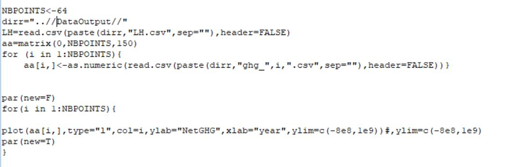

# C-FoodTimeSeriesBasisAndGPEmul.r

In this file, we have exactly the same type of algorithm. Note that in this file, there are 2 directory folders. In my original code, I didn’t save all the objects in the same folder. You can then use the same folder for both directories. To run the code, directory ExampleDirectory needs to contain the Food percentage time series.

# D-Maps_And_OtherTS_Basis_andEmulators_DGPFit.r

Similarly to the previous file, there are 2 directories as the files I was using were stored separately but the 2 folder paths can be the same.

# E-OtherTS_RefitGps.r

The original fits of the planting time series (in D) were done using Deep GPs. However, to calculate many values of the time serires as in file F, the planting time series are refitted in this file with GPs instead of Deep GPs. Note that this file may be removed in later versions as we may decide to only keep one type of fit for the planting time series.

# F-CalcImplausibilityAndTSYr2050.r

In this file, 100,000 values of vector X are randomly chosen and the Implausibility and other time series values are calculated.

# G-HeatBar.r

Code for the Heatbar that is used in the Rshiny app.

# H and I

These files are the radar plots that are pasted on the Rshiny app. File H contains the Radar plot where each line of the radar plot is one of the outputs, I is the radar plot with each line an input to the model X.

# J

In this file, we calculate the ylim ranges for each chart based on simulated data.